# roastgsa vignette (RNAseq)

Adria Caballe-Mestres

15 August 2023

# 1 Installation

```r
if (!require("BiocManager", quietly = TRUE))
    install.packages("BiocManager")
BiocManager::install("roastgsa")
```

# 2 roastgsa in RNA-seq data

This vignette explains broadly the main functions for applying `roastgsa` in RNA-seq data. A more exhaustive example to explore the `roastgsa` functionality is presented in the “roastgsa vignette (main)”. All the analyses explained in the main vignette can be reproduced for RNA-seq data, after undertaking the steps covered here in the section “Data normalization and filtering”.

```r
library( roastgsa )
```

# 3 Data: RNA-seq experiment from GSEABenchmarkeR

We consider the first dataset available in the `tcga` compendium from the `GSEABenchmarkeR` package [1], which consists of a RNA-seq study with 19 tumor Bladder Urothelial Carcinoma samples and 19 adjacent healthy tissues.

```r
#library(GSEABenchmarkeR)
#tcga <- loadEData("tcga", nr.datasets=1,cache = TRUE)
#ysel <- assays(tcga[[1]])$expr
#fd <-  rowData(tcga[[1]])
#pd <- colData(tcga[[1]])
data(fd.tcga)
data(pd.tcga)
data(expr.tcga)

fd <- fd.tcga
ysel <- expr.tcga
pd <- pd.tcga
N  <- ncol(ysel)

head(pd)
```

```
## DataFrame with 6 rows and 4 columns
##                                              sample     type     GROUP
##                                         <character> <factor> <numeric>
## TCGA-K4-A3WV-01A-11R-A22U-07 TCGA-K4-A3WV-01A-11R..     BLCA         1
## TCGA-BT-A20W-01A-21R-A14Y-07 TCGA-BT-A20W-01A-21R..     BLCA         1
## TCGA-K4-A5RI-01A-11R-A28M-07 TCGA-K4-A5RI-01A-11R..     BLCA         1
## TCGA-BT-A20N-01A-11R-A14Y-07 TCGA-BT-A20N-01A-11R..     BLCA         1
## TCGA-BL-A13J-01A-11R-A277-07 TCGA-BL-A13J-01A-11R..     BLCA         1
## TCGA-BT-A20U-01A-11R-A14Y-07 TCGA-BT-A20U-01A-11R..     BLCA         1
##                                     BLOCK
##                               <character>
## TCGA-K4-A3WV-01A-11R-A22U-07 TCGA-K4-A3WV
## TCGA-BT-A20W-01A-21R-A14Y-07 TCGA-BT-A20W
## TCGA-K4-A5RI-01A-11R-A28M-07 TCGA-K4-A5RI
## TCGA-BT-A20N-01A-11R-A14Y-07 TCGA-BT-A20N
## TCGA-BL-A13J-01A-11R-A277-07 TCGA-BL-A13J
## TCGA-BT-A20U-01A-11R-A14Y-07 TCGA-BT-A20U
```

```r
cnames <- c("BLOCK","GROUP")
covar <- data.frame(pd[,cnames,drop=FALSE])
covar$GROUP <- as.factor(covar$GROUP)
colnames(covar) <- cnames
print(table(covar$GROUP))
```

```
##
##  0  1
## 19 19
```

# 4 Data normalization and filtering

To apply `roastgsa`, the expression data should be approximately normally distributed, at least in their univariate form. Depending on the user’s preferred method for differential expression analysis, counts transformation methods such as `rlog` or `vst` (`DESeq2`) [2], `zscoreDGE` (`edgeR`) [3] or `voom` (`limma`) [4], can be applied. In the paper we explored the type I and type II errors when applying the `rlog` or `vst` transformation followed by `roastgsa`, showing both good control of type I errors and decent true discovery rates. In the example presented here we transform the expression data with `vst` function from `DESeq2` R package

```r
library(DESeq2)
dds1 <- DESeqDataSetFromMatrix(countData=ysel,colData=pd,
    design= ~ BLOCK + GROUP)
dds1 <- estimateSizeFactors(dds1)
ynorm <- assays(vst(dds1))[[1]]
colnames(ynorm) <- rownames(covar) <- paste0("s",1:ncol(ynorm))
```

Another key step before using the roastgsa methods for enrichment analysis is to filter out low expressed genes, where coverage might be a limitation for detecting true differentially expressed genes. For the TCGA data considered here, the default filter employed by the authors when loading the data was to exclude genes with cpm < 2 in more than half of the samples. A short discussion about the relationship between gene coverage and statistical power for the `roastgsa` approach is available in our article presenting the `roastgsa` package.

```r
threshLR <- 10
dim(ysel)
```

```
## [1] 3621   38
```

```r
min(apply(ysel,1,mean))
```

```
## [1] 88.26316
```

# 5 Gene sets

We consider a classic repository of general biological functions for battery gene set analysis such as broad hallmarks [5]. The gene sets for human are saved within the roastgsa package and can be loaded by

```r
data(hallmarks.hs)
head(names(hallmarks.hs))
```

```
## [1] "HALLMARK_TNFA_SIGNALING_VIA_NFKB"    "HALLMARK_HYPOXIA"
## [3] "HALLMARK_CHOLESTEROL_HOMEOSTASIS"    "HALLMARK_MITOTIC_SPINDLE"
## [5] "HALLMARK_WNT_BETA_CATENIN_SIGNALING" "HALLMARK_TGF_BETA_SIGNALING"
```

In this case, `hallmarks.hs` contains gene symbols whereas the row names for `ynorm` are entrez identifiers. We can set the row names to symbols, which in this case presents a one-to-one relationship

```r
rownames(ynorm) <-fd[rownames(ynorm),1]
```

Other gene set databases that could be applied to these data for battery testing are presented in the `roastgsa` vignette (gene set collections).

# 6 Enrichment analysis

The comparison of interest can be specified by a numeric vector with length matching the number of columns in the design.

```r
form <- as.formula(paste0("~ ", paste0(cnames, collapse = "+")))
design <- model.matrix(form , data = covar)
terms <- colnames(design)
contrast <- rep(0, length(terms))
contrast[length(colnames(design))] <- 1
```

Below, there is the standard `roastgsa` instruction (under competitive testing) for `maxmean` and `mean` statistics.

```r
fit.maxmean <- roastgsa(ynorm, form = form, covar = covar,
    contrast = contrast, index = hallmarks.hs, nrot = 500,
    mccores = 1, set.statistic = "maxmean",
    self.contained = FALSE, executation.info = FALSE)
f1 <- fit.maxmean$res
rownames(f1) <- gsub("HALLMARK_","",rownames(f1))
head(f1)
```

```
##                total_genes measured_genes        est       nes        pval
## E2F_TARGETS            200            194  1.4694371  4.390076 0.001996008
## G2M_CHECKPOINT         200            188  1.1752646  4.378442 0.001996008
## MYOGENESIS             200            155 -0.8304752 -2.840271 0.005988024
## DNA_REPAIR             150            139  0.4458200  2.646252 0.009980040
## MYC_TARGETS_V2          58             58  1.0304122  2.633228 0.017964072
## MYC_TARGETS_V1         200            192  0.7727287  2.625138 0.025948104
##                 adj.pval
## E2F_TARGETS    0.0332668
## G2M_CHECKPOINT 0.0332668
## MYOGENESIS     0.0748503
## DNA_REPAIR     0.0998004
## MYC_TARGETS_V2 0.1122754
## MYC_TARGETS_V1 0.1297405
```

```r
fit.mean <- roastgsa(ynorm, form = form, covar = covar,
    contrast = contrast, index = hallmarks.hs, nrot = 500,
    mccores = 1, set.statistic = "mean",
    self.contained = FALSE, executation.info = FALSE)
f2 <- fit.mean$res
rownames(f2) <- gsub("HALLMARK_","",rownames(f2))
head(f2)
```

```
##                           total_genes measured_genes        est       nes
## E2F_TARGETS                       200            194  1.1896796  2.802509
## G2M_CHECKPOINT                    200            188  0.9287256  2.676708
## UNFOLDED_PROTEIN_RESPONSE         113            104  0.4270303  2.608516
## MYOGENESIS                        200            155 -0.7076989 -2.319680
## UV_RESPONSE_DN                    144            134 -0.5941011 -2.271648
## DNA_REPAIR                        150            139  0.4878909  2.198412
##                                  pval  adj.pval
## E2F_TARGETS               0.001996008 0.0499002
## G2M_CHECKPOINT            0.005988024 0.0998004
## UNFOLDED_PROTEIN_RESPONSE 0.001996008 0.0499002
## MYOGENESIS                0.009980040 0.0998004
## UV_RESPONSE_DN            0.009980040 0.0998004
## DNA_REPAIR                0.017964072 0.1283148
```

## 6.1 Visualization of the results

Several graphics can be obtained to complement the table results in `f1` and `f2`. Here we only show the heatmaps that summarize the expression patterns obtained for all tested hallmarks. Full description and usage of all graphical options available in the `roastgsa` package are considered in the `roastgsa` vignette for arrays data and the `roastgsa` manual

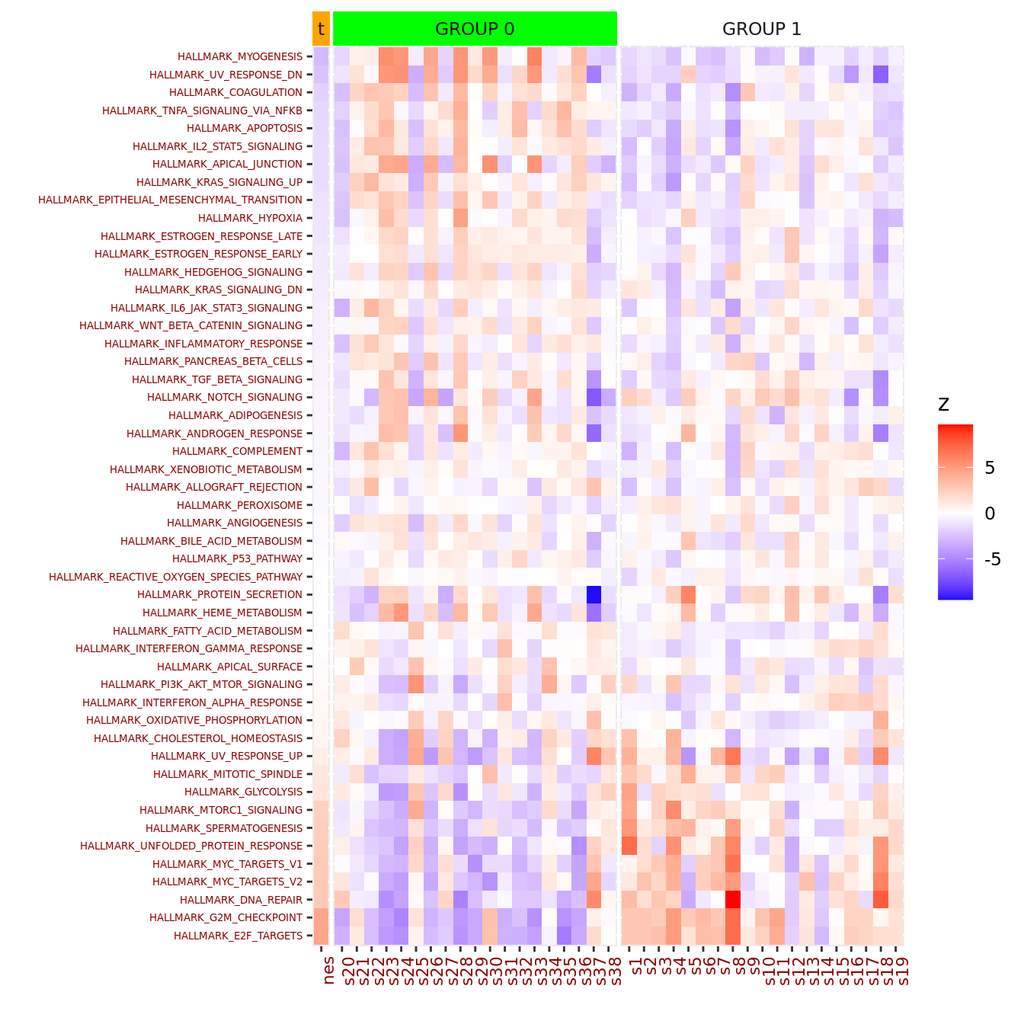

```r
hm1 <- heatmaprgsa_hm(fit.maxmean, ynorm, intvar = "GROUP", whplot = 1:50,
        toplot = TRUE, pathwaylevel = TRUE, mycol = c("orange","green",
        "white"), sample2zero = FALSE)
```

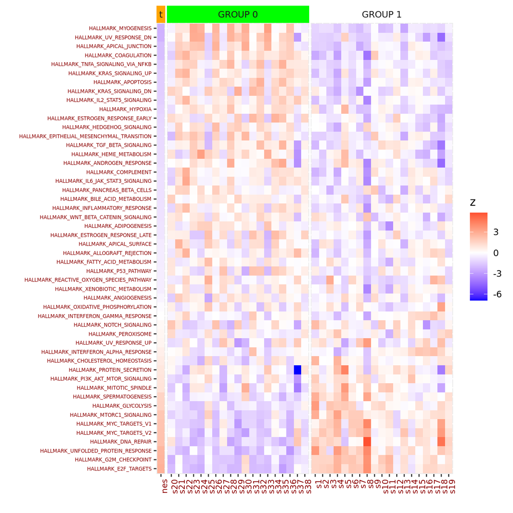

```r
hm2 <- heatmaprgsa_hm(fit.mean, ynorm, intvar = "GROUP", whplot = 1:50,
        toplot = TRUE, pathwaylevel = TRUE, mycol = c("orange","green",
        "white"), sample2zero = FALSE)
```

# 7 References

# Appendix

[1] Geistlinger L, Csaba G, Santarelli M, Schiffer L, Ramos M, Zimmer R, Waldron L (2019). GSEABenchmarkeR: Reproducible GSEA Benchmarking. R package version 1.6.0, https://github.com/waldronlab/GSEABenchmarkeR.

[2] Love MI, Huber W, Anders S (2014). Moderated estimation of fold change and dispersion for RNA-seq data with DESeq2. Genome Biology, 15, 550. doi:10.1186/s13059-014-0550-8.

[3] Robinson MD, McCarthy DJ, Smyth GK (2010). edgeR: a Bioconductor package for differential expression analysis of digital gene expression data. Bioinformatics, 26(1), 139-140. doi:10.1093/bioinformatics/btp616.

[4] M. E. Ritchie, B. Phipson, D. Wu, Y. Hu, C. W. Law, W. Shi, and G. K. Smyth. limma powers differential expression analyses for RNAsequencing and microarray studies. Nucleic acids research, 43(7):e47, 2015.

[5] A. Liberzon, C. Birger, H. Thorvaldsdottir, M. Ghandi, J. P. Mesirov, and P. Tamayo. The Molecular Signatures Database Hallmark Gene Set Collection. Cell Systems, 1(6):417-425, 2015.